# 地理信息系统与R－地图的数据类型与读取

# 空间数据读取

常见的空间数据格式为`*.shp`文件，我在这里不去解析这个文件结构了，你只要知道这个文件可以被`maptools`包中的`readShapePoly`函数读取为`sp`包的空间数据格式就可以了。使用`rgdal`包中的`readOGR`函数也可以实现类似的功能。当我们将常见数据转换到`sp`包的数据类型后，我建议使用`raster`包中的函数`raster`转换为`raster`包内的数据类型。原因是这个包提供了更丰富的GIS函数功能，不过眼下我们只关注画出图来，这个可以不考虑（其实也可以[直接](http://www.r-bloggers.com/converting-shapefiles-to-rasters-in-r/)用`raster`包读取`*.shp`文件）。在数据读取时，你最好注意下原始数据的坐标投影方式，例如：

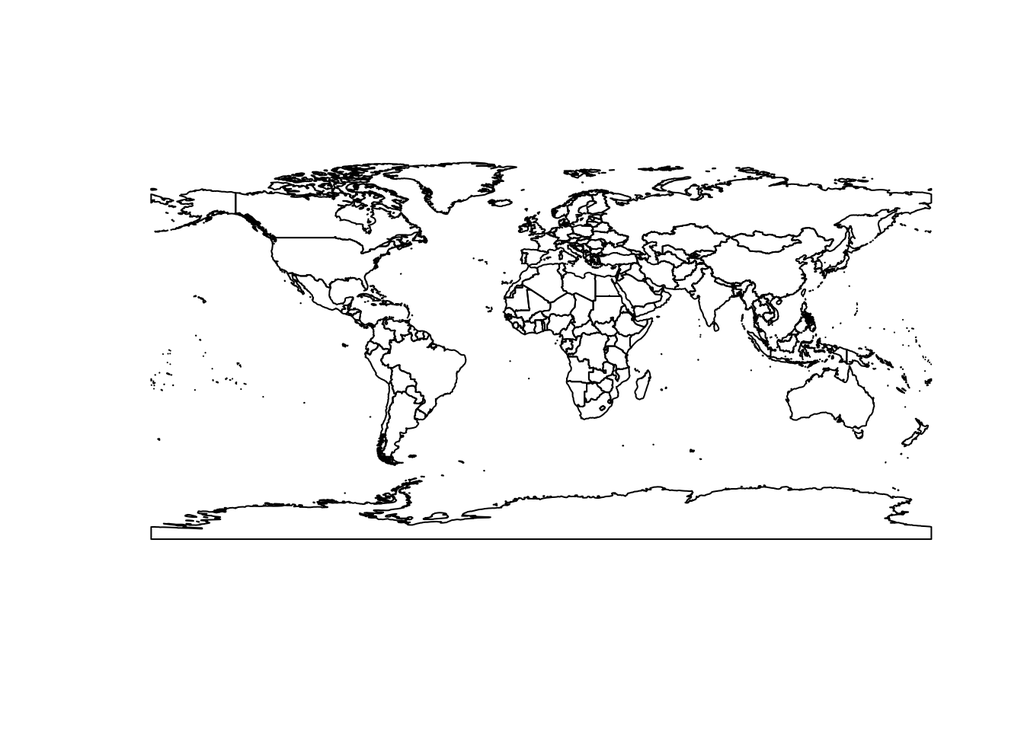

```r
# rworldmap提供了很多现成的地图
library(rworldmap)
# 来张地球行政图
data(countriesLow)
plot(countriesLow)
```

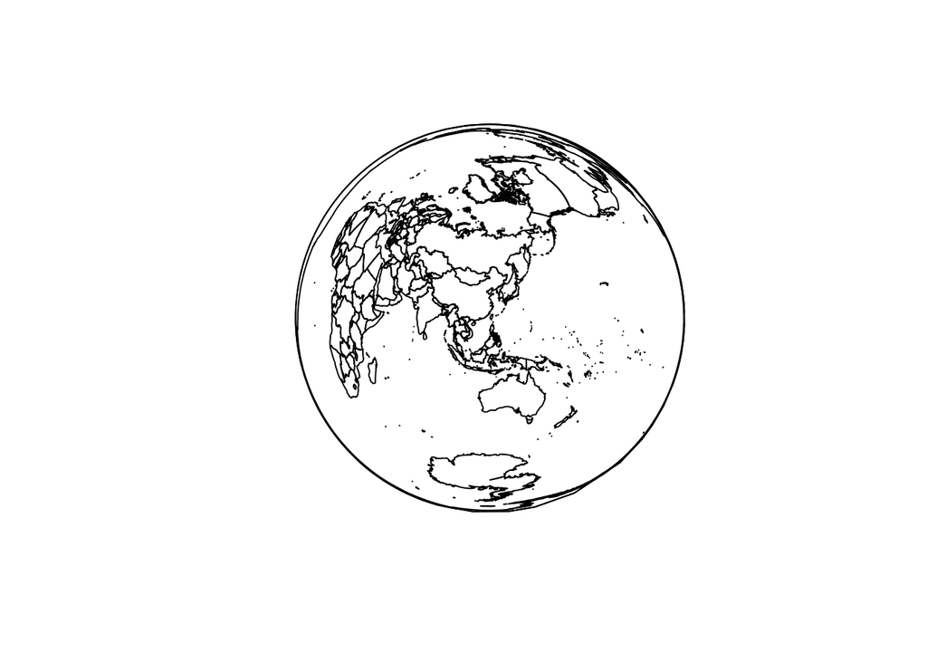

```r
# 更换投影方式
library(rgdal)
country <- spTransform(countriesLow, CRS("+proj=laea +lat_0=23 +lon_0=120 +ellps=GRS80 +units=m +no_defs"))
# 再次绘图
plot(country)
```

# 其他开源GIS工具

R本身是一个命令行软件，你要说用R去自动描底图不是不行，大概你得搞清楚一些图像处理中的边缘检测算法。当然也有例如`GeoXp`这样提供良好交互界面的包可供选择，但我的建议是：专业的事让专业的软件去做，R的优势在于统计分析，具体到地理信息系统中就是空间数据的统计分析。理想的状态应该是我们直接导入成型的地图数据然后展开后续分析，但如果你真的打算自己去描图，我推荐使用开源软件[qGIS](http://qgis.osgeo.org/en/site/index.html)，描完了再导入到R里面分析，实际是python与R间的交流，已经有人写好了数据接口，此外R与qGIS都可通过[PostGIS](http://postgis.net/)做后台数据库，你要是熟悉SQL语法可能用这套系统更熟悉。关键词我已经给够了，请搜索自学，[这里](http://www.osgeo.org/)是个不错的起点。

其实现在很多R包都提供了一些现成的数据或数据接口，我们不用去费事理解数据结构，基本只要给出我感兴趣的经纬度范围或者国家或者地名就可以提取相应的地图。